# Computational tools for the multiscale analysis of HiC data in bacterial chromosomes

*N. Varoquaux, V. S. Lioy., F. Boccard, I. Junier*

We present a multiscale analysis framework we developed to better apprehend the internal structure of *Pseudomonas aeruginosa*'s chromosome. Note that the code here is developed specifically to analyse a unique circular chromosome and needs to be adapted for non-circular chromosomes and multi-chromosome analysis. Yet, the general principal applies to any organism.

This notebook is divided in 6 main sections:

1. Loading libraries and setting options
2. Loading and manipulating Hi-C data with numpy ndarrays
3. Contact law $P(s)$: quantifying the dependence of the frequency of contact as a function of the genomic distance $s$
4. Computing frontier maps
5. Precisely identifying frontiers using a frontier index
6. Assessing the presence of a frontier through a permutation test

# 1. Loading libraries and setting options

The first step is to import all Python packages we will need for this analysis. This allows to check that all Python libraries have been installed properly.

```python
import os
import sys
import numpy as np
import matplotlib.pyplot as plt
from matplotlib import colors
from statsmodels.stats.multitest import multipletests

from scipy.ndimage.filters import gaussian_filter as gf
```

Now set some Matplotlib options to ease the visualization of the results.

```python
%matplotlib inline
plt.rcParams['legend.numpoints'] = 1
plt.rcParams['figure.dpi'] = 150
#plt.rcParams['figure.figsize'] = 5, 4
plt.rcParams['font.size'] = 8
```

## Global parameters

We are also going to define some parameters: First, we define the genome length of the bacteria *P. aeruginosa*. Then we define the resolution of the data we will be using. Here, we decide to focus on a resolution of 10kb.

```python
genome_length = 6275464  # genome length
resolution = 10000
```

# 2. Loading and manipulating Hi-C data with numpy ndarrays

Here, we deal with HiC data obtained in *P. aeruginosa* during its exponential growth in presence of glucose (Lioy *et al.*, in prep.). Sequences were aligned and processed using HiC-pro (Servant *et al.*, 2015) at two resolutions: 1kb and 10kb.

HiC data can be represented as an $n \times n$ symmetric matrix $C$, where each row and each column corresponds to a "locus," "bin," or a genomic window of specific size (which is refered to as the resolution of the data), and each entry $c_{ij}$ corresponds to the number of times the loci $i$ and $j$ have been seen interacting with one another. As a result, the `ndarray` type of `numpy` is an ideal data structure to hold and manipulate Hi-C contact count.

```python
# Identify the size of the ndarray.
n_bins = int(np.ceil(genome_length / resolution))
print("Number of bins:", n_bins)
```

```
Number of bins: 628
```

The size of the matrix for *P. aeruginosa* at 10kb is thus $628 \times 628$.

Let us now create a small utility function to load the HiC contact counts.

```python
def load_HiC(filename, n_bins):
    """Load HiC data

    Reads the Hi-C data from a matrix filename.

    Parameters
    ----------
    filename : string
        path to the file containing the Hi-C count data.

    n_bins : integer
        number of bins of the Hi-C matrix

    Returns
    -------
    (n_bins, n_bins) ndarray containing the count data.
    """

    counts = np.zeros((n_bins, n_bins))
    for line in open(filename).readlines():
        content = line.split()

        # ndarray index starts at 0 while the Hi-C pro
        # matrix format starts at 1.
        i, j = int(content[0])-1, int(content[1])-1
        counts[i, j] = float(content[2])
        counts[j, i] = counts[i, j]

    return counts
```

And now we load the HiC data at the desired resolution.

```python
hic_counts = load_HiC("data/res%d.txt" % resolution, n_bins)
```

We can check the contact count is the correct size.

```python
print("Shape of the ndarray:", hic_counts.shape)
print("Content of the ndarray:\n", hic_counts)
```

```
Shape of the ndarray: (628, 628)
Content of the ndarray:
 [[  57.768161   97.018265   63.878714 ...   91.268313  120.397202
  1762.78889 ]
 [  97.018265   74.548234  110.786006 ...   49.440247   50.616938
    43.991386]
 [  63.878714  110.786006  114.619009 ...   53.537229   65.846501
    65.363009]
 ...
 [  91.268313   49.440247   53.537229 ...  165.680061  282.296063
   182.645183]
 [ 120.397202   50.616938   65.846501 ...  282.296063  326.865348
   400.307949]
 [1762.78889    43.991386   65.363009 ...  182.645183  400.307949
   200.629649]]
```

Note that the contact count is not composed of integers. This is because we loaded the normalized contact count matrix to remove biases. More is explained below.

## 2.1 ICE normalization

The ICE normalization assumes that a locus should interact equally as much as any other loci. As a result, after normalization, the sum of contact frequency for each loci should be equal. Hence, it transforms an integer matrix into a float matrix.

Let us plot the cumulative contact frequency along the genome to check the normalization has converged correctly.

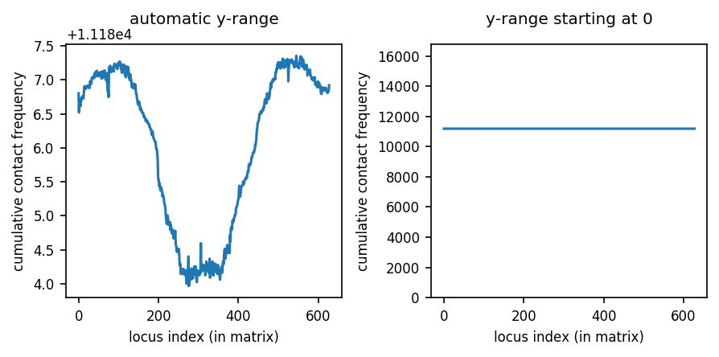

```python
# cumulative frequencies for each bin
cumul_freq = np.sum(hic_counts, axis=0)

# using two ranges for visualization of cumulative frequencies
fig, axes = plt.subplots(figsize=(6, 3), ncols=2, tight_layout=True)
for i, ax in enumerate(axes):
    ax.plot(cumul_freq)
    ax.set_xlabel('locus index (in matrix)')
    ax.set_ylabel('cumulative contact frequency')
    if i == 1:
        ax.set_ylim([0, 1.5*np.max(cumul_freq)])
        ax.set_title('y-range starting at 0', pad=12)
    else:
        ax.set_title('automatic y-range', pad=12)
```

The plotting library `Matplotlib` automatically sets the range of the axes. As a result, it can seem that the cumulative contact frequency for each loci is not identical. Setting the range manually between 0 and the maximum cumulative frequency (times 1.5 to plot the line roughly in the middle of the axis) demonstrates that the normalization was successful.

## 2.2 Further normalization such that cumulative frequencies = 1

We will further normalize the data such that the cumulative frequencies are equal to one. This allows to set all datasets to roughly the same value. The rest of the pipeline does not depend on this rescaling step and one may prefer to work with the unscaled data.

```python
hic_counts /= np.mean(np.sum(hic_counts, axis=0))
```

Let us now visualize the cumulative frequencies for each locus again. The cumulative frequencies should now sum to one.

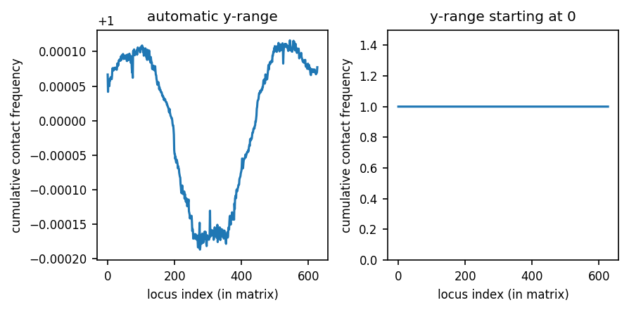

```python
# cumulative frequencies for each bin...
cumul_freq =  np.sum(hic_counts, axis=0)

#using two ranges for visualization of cumulative fr.eq.u.encies
fig, axes = plt.subplots(ncols=2, figsize=(6, 3), tight_layout=True)
for i, ax in enumerate(axes):
    ax.plot(cumul_freq)
    ax.set_xlabel('locus index (in matrix)');
    ax.set_ylabel('cumulative contact frequency')
    if i == 1:
        ax.set_ylim([0, 1.5*np.max(cumul_freq)])
        ax.set_title('y-range starting at 0')
    else:
        ax.set_title('automatic y-range')
```

As expected, the resulting cumulative contact frequency sums to one.

## 2.3 Changing the center of the heat map using the roll function of numpy

Remember that *P. aeruginosa* is composed of one chromosome and this chromosome is circular. As a result, there is no "beginning" and "end" of a chromosome as one would see on other dataset. We can use the `np.roll` function of numpy to change the original of the contact map. We will use `Matplotlib`'s `imshow` function to visualize the data as a heatmap.

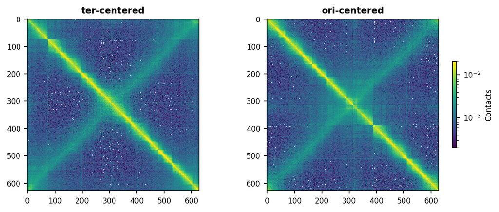

```python
res = 10000

fig, axes = plt.subplots(figsize=(8, 3.2), ncols=2, tight_layout=True)
fig.subplots_adjust(right=0.9)


m = axes[0].imshow(
    hic_counts,
    norm=colors.LogNorm(),
    interpolation="none",
    vmin=0.0002, vmax=0.02, cmap='viridis')
axes[0].set_title('ter-centered', fontweight="bold")

# changing the center oif the heat map
ori_centered = np.roll(
    hic_counts, int(len(hic_counts)/2), (0, 1))
m = axes[1].imshow(
    ori_centered, norm=colors.LogNorm(),
    interpolation="none",
    vmin=0.0002, vmax=0.02, cmap='viridis')
axes[1].set_title('ori-centered', fontweight="bold")
cb = fig.colorbar(m, shrink=0.5, ax=axes[1])
cb.set_label("Contacts")

fig.savefig('figures/heat_maps_res%d.pdf'%(res), transparent=True)
```

We can see that whatever the origin of the contact count matrix, two feature remains: the strong main diagonal and the secondary lighter diagonal. The former is a staple of Hi-C dataset: this diagonal shows that elements that are nearby in terms of genomic distance are in close 3D proximity and, hence, interact often. The secondary less pronounced diagonal reflects the longitudinal organization of *P. aeruginosa* chromosome where loci that are located symmetrically with respect to the origin of replication often interact.

# 3. Contact law $P(s)$: quantifying the dependence of the frequency of contact as a function of the genomic distance $s$

## 3.1 Estimating P(s) and the associated statistics

Let us now estimate the contact law $P(s)$ to study the dependency of the frequency of contact between any two sites as a function of the genomic distance $s$. $P(s)$ is simply given by the mean of the hic counts for all pairs of loci $(i, j)$ for $|i - j| = s$. Importantly, the absolute value of these mean frequencies are unknown as they include a global (unknown) factor, i.e. $P(s)=P_T(s)/\mathcal{N}$ where $\mathcal{N}$ is this factor and $P_T(s)$ the true mean frequency.

The shape of $P(s)$ as a function of $s$ nevertheless provides useful information to e.g. develop realistic polymer models to explain data (Mirny, Chromosome Res., 2011).

In addition to the mean, here, we compute the asscoiated stantard deviation and standard error of the mean for each genomic distance s.

Let us implement a small function that takes the normalized count as input and returns the corresponding statistics.

```python
def Ps_index(counts):
    """
    Compute the contact law P(s) of a bacteria chromosome.

    Method: (contacts at distance s are found on the s^th and (N-s)^th diagonal)
        1. for a given s, extract the s^th and (N-s)^th diagonal
        2. compute the associated stat

    Parameters
    -----------
    counts : ndarray of shape (n, n)
        Contact count matrix

    Returns
    -------
    tuple of ndarrays of shape (n, )
        - mean at each genomic distance s
        - Standard deviation at each genomic distance s
        - Standard error at each genomic distance s
    """

    N = len(counts)
    # Careful! Bacteria chromosomes are circular: hence, a genomic distance
    # s corresponds to two "diagonals"
    mean = np.array(
        [np.mean(np.concatenate([np.diag(counts, i), np.diag(counts, N-i)]))
         for i in range(int(N/2)+1)])
    std = np.array(
        [np.std(np.concatenate((np.diag(counts, i), np.diag(counts, N-i))))
         for i in range(int(N/2)+1)])
    stde = std / np.sqrt((N-1))
    return mean, std, stde
```

Now apply this function to *P. aeruginosa*.

```python
contact_law_mapping = Ps_index(hic_counts)
```

And visualize the contact law with different scales on the x- and y-axis.

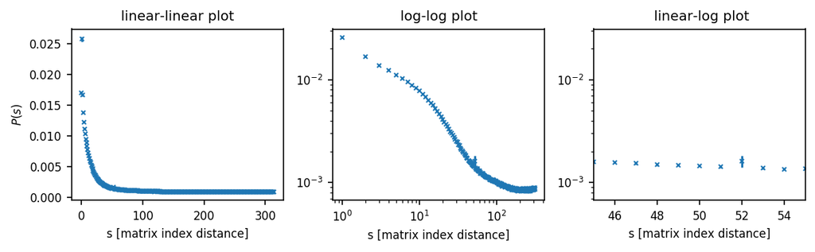

```python
fig, axes = plt.subplots(figsize=(8, 2.5), ncols=3, tight_layout=True)
scalings = ['linear-linear plot', 'log-log plot',' linear-log plot']
for i, title in enumerate(scalings):
    ax = axes[i]
    ax.errorbar(
        x=np.arange(len(contact_law_mapping[0])),
        y=contact_law_mapping[0],
        yerr=contact_law_mapping[2],
        fmt='x',
        ms=3)

    # scales, ranges
    if i == 1:
        ax.set_xscale('log')
        ax.set_yscale('log')
    if i == 2:
        ax.set_xlim([45, 55])
        ax.set_yscale('log')

    # Add title and labels
    ax.set_title(title)
    ax.set_xlabel(r's [matrix index distance]')
    if i == 0:
        ax.set_ylabel(r'$P(s)$')
```

**Note:** the point off the curves in the linear-log plot stems from the presence of a repeated sequence and, hence, reflects a sequence mapping problem during the bowtie2 stage of sequence counting.

The implementation above uses a linear binning: the mapping is estimated for $s$ ranging linearly along the genome. Sometimes, it is more appropriate to use an uneven binning. Here, we propose another implementation to estimate the contact law $P(s)$ with a geometric binning of the genomic distance $s$, thus using smaller bins for shorter distance and larger bins for longer distance, reflecting the larger confidence in shorter distances than longer distances.

```python
def compute_Ps(H, H_res, s0, binning='lin'):
    """
    Inputs:
        H: HiC matrix
        H_res: HiC matrix resolution
        s0: binning step of s for the linear case; smallest genomic distance for the geometric case
        binning: if not 'lin' (linear binning), it indicates the number of bins to use to build the geometric binning of the genomic distance (s)

    Return: contact law P(s) between s=0 (s0 for the geometric case) and s=Lg/2, where s stands for the genomic distance in base pairs

    Method:
        1. binning of the genomic distances (linear or geometric)
        2. extract diagonal indexes corresponding to each bin (idiag)
        3. compute the associated stat

    Options:
        binning='lin' => linear binning between 0 and Lg/2 with step s0
        binning=integer => geometric binning between s0 and Lg/2 with the number of bins given by "binning"
    """
    if s0 < H_res:
        raise ValueError('Error: Ps bin size (s0) must be larger than H resolution')

    N = len(H)

    # 1. binning
    if binning =='lin':
        bins = [iPs*s0 for iPs in range(int(N*H_res/(2*s0))+1)]
    elif isinstance(binning, int):
        r = np.power(N*H_res/(2*s0), 1/binning)
        bins = [s0*np.power(r,iPs) for iPs in range(binning+1)]
    else:
        raise ValueError('Error: unknown binning option')

    # 2. diagonal indexes corresponding to binning
    idiag = [
        [i for i in range(int(bins[iPs]/H_res), np.max((int(bins[iPs+1]/H_res), int(bins[iPs]/H_res)+1)))]
         for iPs in range(len(bins)-1)]

    # 3. stat
    s = [np.mean([i*H_res for i in ids]) for ids in idiag]
    mean = [
        np.mean(np.concatenate((np.concatenate([np.diag(H,i)
                                                for i in ids]),
                                np.concatenate([np.diag(H, N-i)
                                                for i in ids]))))
        for ids in idiag]
    std = [
        np.std(np.concatenate(
            (np.concatenate([np.diag(H,i) for i in ids]),
             np.concatenate([np.diag(H,N-i) for i in ids]))))
        for ids in idiag]
    stde = std / np.sqrt((N-1))

    return s, mean, std, stde
```

Let us now compare the geometric binning with the linear binning on *P. aeruginosas* at 10kb.

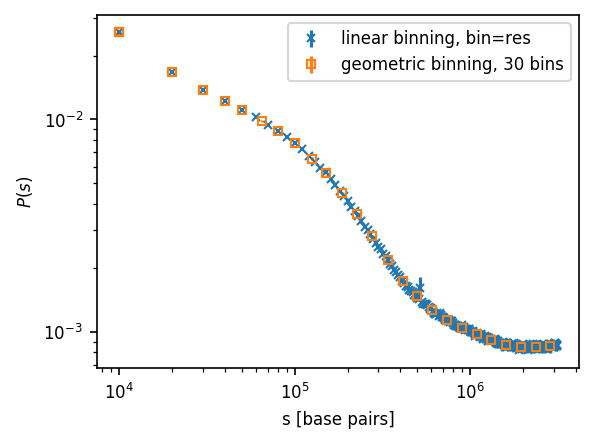

```python
Ps = compute_Ps(hic_counts, resolution, 1*resolution)
contact_law_linear = compute_Ps(hic_counts, resolution, resolution)

fig, ax = plt.subplots(tight_layout=True, figsize=(4, 3))
ax.errorbar(
    x=contact_law_linear[0],
    y=contact_law_linear[1],
    yerr=contact_law_linear[3],
    fmt='x', ms=4, label='linear binning, bin=res')

contact_law_geom = compute_Ps(
    hic_counts, resolution, resolution, binning=30)
ax.errorbar(
    x=contact_law_geom[0], y=contact_law_geom[1],
    yerr=contact_law_geom[3],
    fmt='s', ms=4, label='geometric binning, 30 bins', mfc='none')

ax.set_xscale('log')
ax.set_yscale('log')
ax.set_xlabel(r's [base pairs]');
ax.set_ylabel(r'$P(s)$')
ax.legend(fontsize="medium");

fig.savefig('figures/Ps.pdf', transparent=True)
```

The contact law $P(s)$ with a linear binning and a geometric binning perfectly overlap.

## 3.2 Detecting and solving sequence mapping issues

```
Wrong pair of loci: [472, 524] , with HiC values: 0.13073011535191773
```

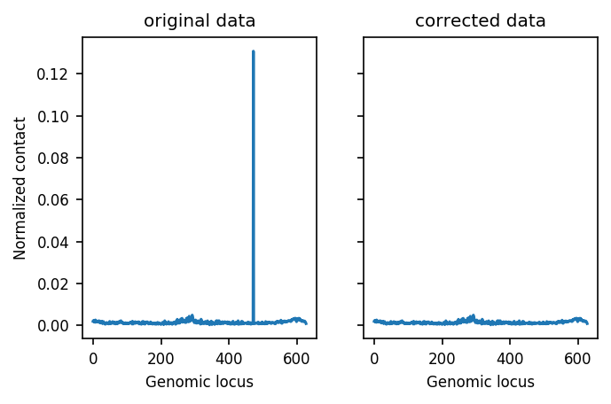

```python
# Extract the 53rd diagonal:
diag = np.concatenate(
    (np.diag(hic_counts, 52),
     np.diag(hic_counts, n_bins-52)))

wrong_index = sorted(
    [i for i in range(len(diag))], key=lambda i:-diag[i])[0]
wrong_pair = [wrong_index, (wrong_index+52) % n_bins]

print('Wrong pair of loci:', wrong_pair,
      ', with HiC values:', hic_counts[wrong_pair[0], wrong_pair[1]])

# Now visualize the diagonal on the original data and the corrected data.
fig, axes = plt.subplots(figsize=(5, 3), ncols=2, sharex=True, sharey=True)
axes[0].plot(diag)
axes[0].set_title('original data')

hic_counts[wrong_pair[0], wrong_pair[1]] = \
    hic_counts[wrong_pair[0]+1,wrong_pair[1]+1]
hic_counts[wrong_pair[1], wrong_pair[0]] = \
    hic_counts[wrong_pair[0],wrong_pair[1]]

diag = np.concatenate((np.diag(hic_counts, 52),
                        np.diag(hic_counts, n_bins - 52)))
axes[1].plot(diag)
axes[1].set_title('corrected data');
axes[0].set_xlabel("Genomic locus");
axes[1].set_xlabel("Genomic locus");
axes[0].set_ylabel("Normalized contact");
```

# 4. Computing frontier maps

We are now going to dive into detecting frontiers of chromosome interaction domains (CID). The first step is to process the contact count matrix to highlight the frontiers of the chromosome interaction domains.

```python
def generate_frontiers(H, w=1):

    """
    Estimate the upstream, downstream and combined frontiers matrices associated with the HiC data (H).

    Method:
        1. substract the mean P(s) component to focus only on the
           variations associated with domains
        2.
            a. smooth the data using e.g. a Gaussian filter so that
               the derivative of the matrix is as less noisy as possible
            b. compute the derivative
            c. extract upstream (downstream) frontiers of loci by keeping negative (positive) derivative values
            along the horizontal (vertical) direction in the upper triangle part of the matrix
        3. build the combined frontier matrix by summing downstream and upstream frontier matrices

    Arguments
    ---------
    H : ndarray
        HiC matrix
    w : float, optional, default: 1
        width associated with a Gaussian smoothing of the data

    Returns
    -------
    a list of three matrices (combined, upstream, downstream) where entries are positive

    """

    N = len(H)

    # 1. H0=H-P(s)
    Ps = [np.mean(np.concatenate([np.diag(H,i), np.diag(H,N-i)]))
          for i in range(N)]
    H0 = np.array(H)
    for i in range(N):
        for j in range(i,N):
            H0[i,j] -= Ps[j-i]
            H0[j,i] = H0[i,j]

    # 2.a. Smooth the data using Gaussian filter (gf() function;
    #      see import modules)
    # 2.b. Compute the derivative of the signal along the vertical
    #      D[0] and horizontal D[1] directions
    # rem: the mode wrap: is used because of periodic conditions
    #     (circular chromosome)
    # 2.c Get the upstream and downstream signals

    def compute_gradient(matrix):
        """Computes the gradient of a 2D matrix with underlying circular structure.

        Parameters
        ----------
        matrix : 2D matrix of shape (n, n)

        Returns
        -------
        two gradient matrices corresponding to the two axis of the input matrix

        """
        gradient_i = np.zeros(matrix.shape)
        gradient_j = np.zeros(matrix.shape)

        gradient_i = matrix - np.roll(matrix, 1, 0)
        gradient_j = matrix - np.roll(matrix, 1, 1)
        return gradient_i, gradient_j

    D = compute_gradient(gf(H0, w, mode='wrap'))

    F_upstream, F_downstream = np.array(D[0]), np.array(D[1])
    # Remove the two diagonals
    np.fill_diagonal(F_upstream, 0)
    np.fill_diagonal(F_downstream, 0)

    F_upstream[F_upstream < 0] = 0
    F_downstream[F_downstream > 0]=0
    F_downstream = np.abs(F_downstream)

    for A in [F_upstream, F_downstream]:
        for i in range(int(len(A)/2)+1,len(A)):
            np.fill_diagonal(A[:,i:],0)
        for i in range(int(len(A)/2)+1):
            np.fill_diagonal(A[i:],0)

    # 3. Building the "frontier" matrix
    F = F_upstream + F_downstream
    # symmetrization of the matrix;
    F = F + np.transpose(F)

    return F, F_upstream, F_downstream
```

Now compute the frontiers matrix on *P. aeruginosa*'s contact count matrix.

```python
frontiers_matrix = generate_frontiers(hic_counts)
```

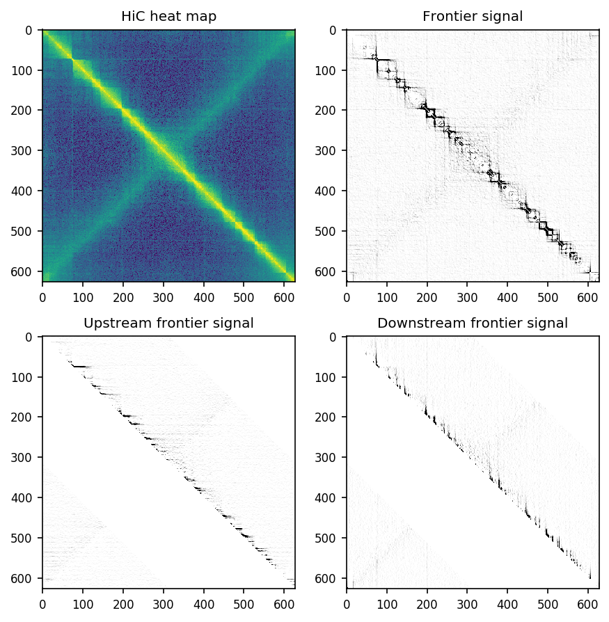

```python
fig, axes = plt.subplots(figsize=(6, 6), ncols=2, nrows=2, tight_layout=True)

axes[0][0].imshow(
    hic_counts,
    norm=colors.SymLogNorm(0.0002),
    vmin=0.0002, vmax=0.02, cmap='viridis')
axes[0][0].set_title('HiC heat map')

axes[0][1].imshow(
    frontiers_matrix[0],
    cmap="Greys",
    vmin=0,
    vmax=0.001);
axes[0][1].set_title('Frontier signal');

axes[1][0].imshow(
    frontiers_matrix[1],
    cmap="Greys",
    vmin=0,
    vmax=0.001);
axes[1][0].set_title('Upstream frontier signal');

axes[1][1].imshow(
    frontiers_matrix[2],
    cmap="Greys",
    vmin=0,
    vmax=0.001);
axes[1][1].set_title('Downstream frontier signal');

fig.savefig('figures/frontiers.pdf', transparent=True)
#np.savetxt("frontiers.matrix", frontiers_matrix[0])
#np.savetxt("frontiers_up.matrix", frontiers_matrix[1])
#np.savetxt("frontiers_down.matrix", frontiers_matrix[2])
```

We can see that the frontier matrix highlight the boundaries of the chromosome interaction domains via vertical and horizontal lines.

Our goal is now going to be to identify those vertical and horizontal lines to identify the loci at the chromosome interaction domain frontiers.

## 5. Precisely identifying frontiers using a frontier index

```python
def compute_frontier_indexes(frontiers_matrix, max_s=50):
    """
    Compute the frontier indexs

    Arguments
    ----------
    frontiers_matrix : ndarray,
        frontier matrix

    max_s : int
        maximum index distance over which the sum os performed

    Returns
    -------
    Upstream, downstream and combined frontier indexes.
    """

    N = len(frontiers_matrix[0])

    if max_s is None:
        max_s = int(N / 2)

    def remove_diagonals_above_k(matrix, k):
        filtered_matrix = matrix.copy()
        N = matrix.shape[0]
        # Remove the upper and lower k-th triangular diagonals.
        filtered_matrix[np.triu_indices_from(matrix, k=k)] = 0
        filtered_matrix[np.tril_indices_from(matrix, k=-k)] = 0

        # Now, add back the upper N-kth triangular matrix
        indices = np.triu_indices_from(matrix, k=N-k)
        filtered_matrix[indices] = matrix[indices]

        # Now, add back the upper N-kth triangular matrix
        indices = np.tril_indices_from(matrix, k=k-N)
        filtered_matrix[indices] = matrix[indices]
        return filtered_matrix


    upstream_matrix = remove_diagonals_above_k(frontiers_matrix[1], k=max_s)
    downstream_matrix = remove_diagonals_above_k(frontiers_matrix[2], k=max_s)

    FI_up = np.sum(upstream_matrix, axis=1)
    FI_down = np.sum(downstream_matrix, axis=0)

    return FI_up, FI_down
```

We now apply this to *P. aeruginosa*'s frontiers matrix and display for each locus the value of the frontier indexes.

Here, we use max_s=50, which corresponds to analyse all domaines up to the 500 kb scale

```python
frontier_index = compute_frontier_indexes(frontiers_matrix, max_s=50)
```

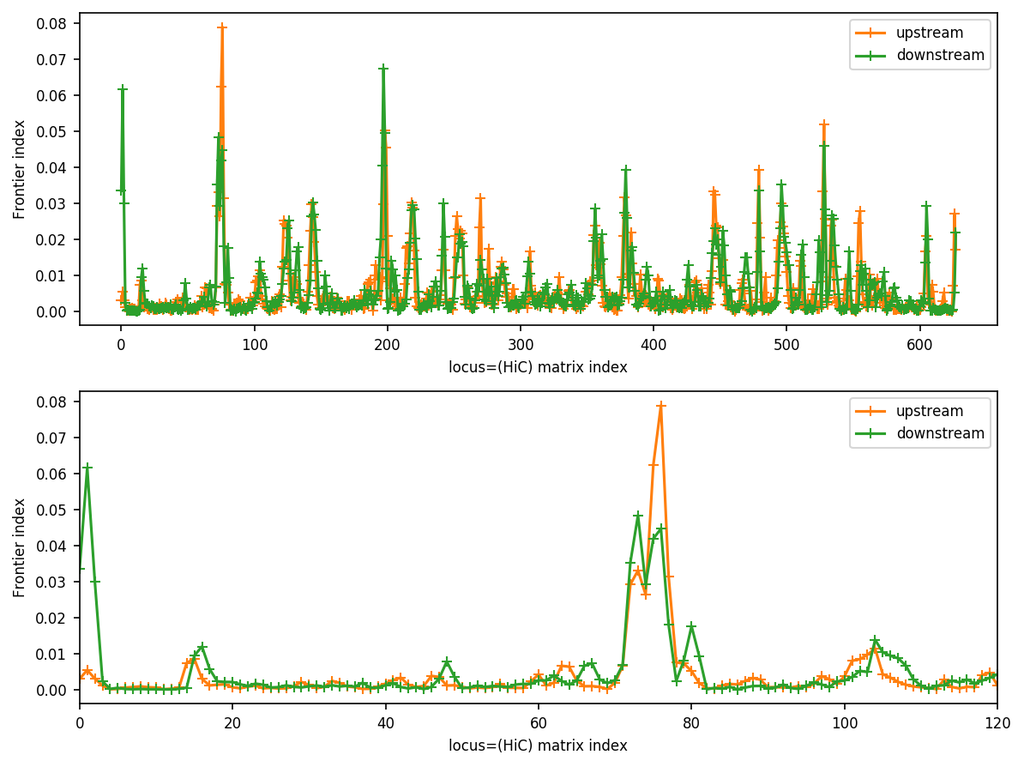

```python
fig, axes = plt.subplots(figsize=(8, 6), nrows=2, tight_layout=True)

for i, (c, lab) in enumerate(zip(['C1','C2'], ['upstream', 'downstream'])):
    axes[0].plot(frontier_index[i], '%s+-'%c,label=lab);

for i, (c, lab) in enumerate(zip(['C1','C2'], ['upstream', 'downstream'])):
    axes[1].plot(frontier_index[i], '%s+-'%c,label=lab);
axes[1].set_xlim([0,120])

for i in [0, 1]:
    axes[i].set_xlabel('locus=(HiC) matrix index');
    axes[i].set_ylabel('Frontier index');
    axes[i].legend(fontsize="medium");
```

```python
def find_peaks(v):
    size = len(v)
    peaks = [
        i for i in range(size)
        if v[(i-1+size)%size]<v[i] and v[i]>v[(i+1)%size]]
    return peaks

peaks = [find_peaks(frontier_index[i]) for i in range(2)]

print("Number of upstream peaks:", len(peaks[0]))
print("Number of downstream peaks:", len(peaks[1]))
```

```
Number of upstream peaks: 140
Number of downstream peaks: 132
```

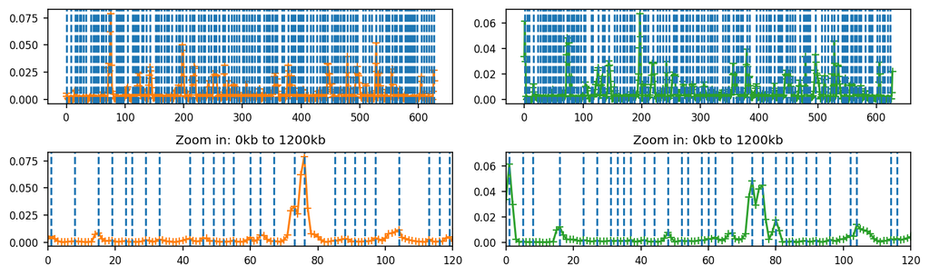

```python
fig, axes = plt.subplots(figsize=(10, 3), nrows=2, ncols=2, tight_layout=True)

for ip, cp in enumerate(['C1','C2']):
    axes[0, ip].plot(frontier_index[ip], "%s+-"%cp)
    [axes[0, ip].axvline(i, linestyle="--",color='C0') for i in peaks[ip]];

    axes[1, ip].plot(frontier_index[ip], "%s+-"%cp)
    [axes[1, ip].axvline(i, linestyle="--",color='C0') for i in peaks[ip]];
    axes[1, ip].set_xlim([0,120])
    axes[1, ip].set_title("Zoom in: 0kb to 1200kb");
```

From just detecting peaks, we can see we have many false positive due to the noise in the frontier index. We can add a filtering step to only consider peaks with a frontier index higher than than a specific value. Here, we set the threshold to the median frontier index value, but it can also be set to an arbitrary value.

```python
median_frontier_index = [np.median(indexes) for indexes in frontier_index]
```

```python
loci_of_interest = [np.where(frontier_index[i] > median_frontier_index[i])[0] for i in range(len(frontier_index))]
filtered_peaks = [loci_of_interest[i][np.isin(loci_of_interest[i], peaks[i])] for i in range(len(frontier_index))]
```

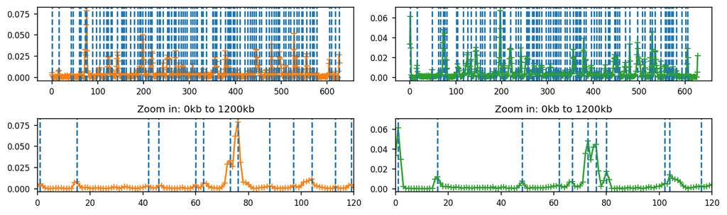

```python
fig, axes = plt.subplots(figsize=(10, 3), nrows=2, ncols=2, tight_layout=True)


for ip, cp in enumerate(['C1', 'C2']):
    axes[0, ip].plot(frontier_index[ip], "%s+-"%cp)
    [axes[0, ip].axvline(i, linestyle="--", color='C0') for i in filtered_peaks[ip]];

    axes[1, ip].plot(frontier_index[ip], "%s+-"%cp)
    [axes[1, ip].axvline(i, linestyle="--", color='C0') for i in filtered_peaks[ip]];
    axes[1, ip].set_xlim([0,120])
    axes[1, ip].set_title("Zoom in: 0kb to 1200kb");
```

```python
for i, s in enumerate(['upstream', 'downstream']):
    print("Number of %s peaks"%s, len(peaks[i]))
    print("Number of filtered %s peaks"%s, len(filtered_peaks[i]), '\n')
```

```
Number of upstream peaks 140
Number of filtered upstream peaks 99

Number of downstream peaks 132
Number of filtered downstream peaks 85
```

Now, let us visualize small proportions of the matrix to observe the frontiers detected through this simple method.

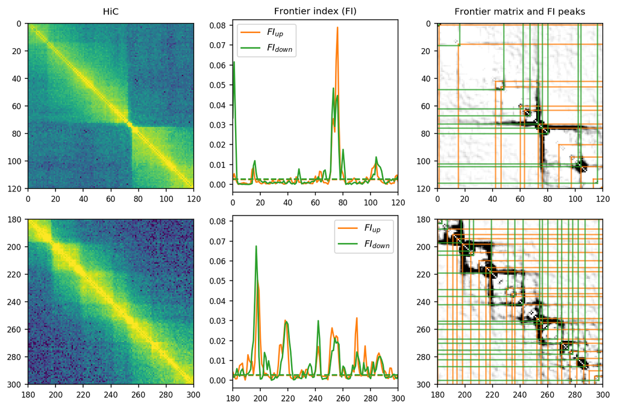

```python
fig, axes = plt.subplots(figsize=(9, 6), ncols=3, nrows=2,tight_layout=True)


for irow in range(2):
    axes[irow, 0].matshow(
        hic_counts,
        norm=colors.SymLogNorm(0.0002),
        vmin=0.0002, vmax=0.02, cmap='viridis')

    axes[irow, 1].plot(frontier_index[0], "C1-",label="$FI_{up}$")
    axes[irow, 1].plot(frontier_index[1], "C2-",label="$FI_{down}$")
    axes[irow, 1].axhline(median_frontier_index[0],color='C1',linestyle='dashed')
    axes[irow, 1].axhline(median_frontier_index[1],color='C2',linestyle='dashed')

    axes[irow, 2].matshow(frontiers_matrix[0],
                cmap=plt.get_cmap('Greys'), vmin=0, vmax=0.001);
    [axes[irow, 2].plot([i, len(hic_counts)], [i, i], color="C1", alpha=0.7)
     for i in filtered_peaks[0]];
    [axes[irow, 2].plot([i, i], [i,len(hic_counts)], color="C1", alpha=0.7)
     for i in filtered_peaks[0]];

    [axes[irow, 2].plot([0, i], [i, i], color="C2", alpha=0.7)
     for i in filtered_peaks[1]];
    [axes[irow, 2].plot([i, i], [0, i], color="C2", alpha=0.7)
     for i in filtered_peaks[1]];

    # Set titles on the plots of the first row
    if irow == 0:
        axes[irow, 0].set_title('HiC', pad=0.5)
        axes[irow, 1].set_title('Frontier index (FI)')
        axes[irow, 2].set_title('Frontier matrix and FI peaks',pad=0.5)

    if irow == 0:
        for j in [0,2]:
            axes[irow, j].set_xlim([0,120])
            axes[irow][j].set_ylim([120,0])
            axes[irow, j].xaxis.set_ticks_position('bottom')
        axes[irow, 1].set_xlim([0, 120])
        axes[irow, 1].legend(loc=2,fontsize='large')
    else:
        for j in [0, 2]:
            axes[irow, j].set_xlim([180, 300])
            axes[irow, j].set_ylim([300, 180])
            axes[irow, j].xaxis.set_ticks_position('bottom')
        axes[irow, 1].set_xlim([180, 300])
        axes[irow, 1].legend(loc=1,fontsize='large')

fig.savefig("figures/frontier_peaks.pdf")
```

## 6. Estimating a null model and relevant FDR

Typically, on Hi-C data, permutation tests are performed by shuffling the elements of contact count matrix for each genomic distance $s$. This results in a randomized matrix that preserves the inherent structure of the contact count matrix, and thus contact law $P(s)$. Here, our statistics is the frontier index, and thus build on a transformation of a contact count matrix. We are thus going to perform a similar randomization, but on the (upstream) frontier matrix.

```python
def randomize_matrix(matrix):
    """
    Randomize matrix preserving the distribution of elements per diagonal

    Arguments
    ---------
    matrix : ndarray (n, n)
        The ndarray to shuffle

    Returns
    -------
    Randomized matrix that preserves the contact law P(s)
    """
    N = len(matrix)
    randomized_matrix = np.zeros(matrix.shape)

    # Draw random samples directly from the data
    indices = np.arange(N)
    np.random.shuffle(indices)
    np.fill_diagonal(randomized_matrix, np.diag(matrix)[indices])

    for s in range(1, int(np.ceil(N / 2))):
        # Start by upper diagonals
        sub_diag = np.concatenate(
            [np.diag(matrix, k=s),
             np.diag(matrix, k=s-N)])
        np.random.shuffle(indices)
        random_elements = sub_diag[indices]
        np.fill_diagonal(
            randomized_matrix.T[s:],
            random_elements[:N-s])
        np.fill_diagonal(
            randomized_matrix[N-s:],
            random_elements[N-s:N])

        # And now lower diagonals
        sub_diag = np.concatenate(
            [np.diag(matrix, k=-s),
             np.diag(matrix, k=N-s)])
        np.random.shuffle(indices)
        random_elements = sub_diag[indices]
        np.fill_diagonal(
            randomized_matrix[s:],
            random_elements[:N-s])
        np.fill_diagonal(
            randomized_matrix.T[N-s:],
            random_elements[N-s:N])

    return randomized_matrix
```

Let us now visualize the randomized upstream frontier matrix.

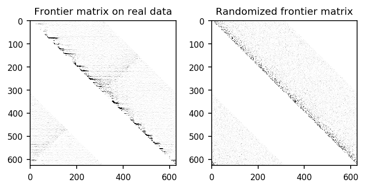

```python
fig, axes = plt.subplots(figsize=(5, 2.5), ncols=2, tight_layout=True)

axes[0].imshow(frontiers_matrix[1], vmin=0, vmax=0.0005, cmap='Greys')
axes[0].set_title('Frontier matrix on real data')

randomize_frontiers = randomize_matrix(frontiers_matrix[1])
axes[1].imshow(randomize_frontiers,
               cmap=plt.get_cmap('Greys'), vmin=0, vmax=0.0005);
axes[1].set_title('Randomized frontier matrix');
```

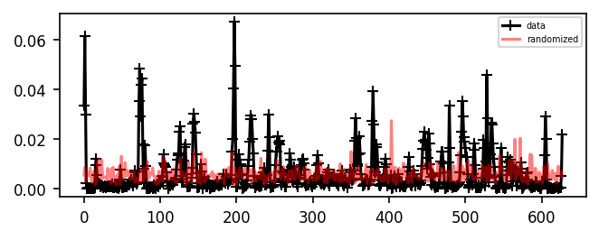

```python
# Now visualize the frontier index for the real data and the randomized frontier signal
fig, ax = plt.subplots(figsize=(5, 1.8))
ax.plot(compute_frontier_indexes(frontiers_matrix)[1], "k+-", label="data")
ax.plot(compute_frontier_indexes((randomize_frontiers, randomize_frontiers,  randomize_frontiers))[1],
        "r-", alpha=0.5, label="randomized")
ax.legend(fontsize="xx-small")
```

From the last plot, we can see that the statistics of the null distribution is likely overestimated.This is because the permutation assumes that there is no correlation between the statistics, while our statistics captures the local correlation between adjacent loci.

We are now going to use this permutation procedure to estimate the null distribution.

Let us first create a small function to get feedback when we run the loop.

```python
#some useful function to get feedback from a running loop (see next cell)
from IPython.core.display import clear_output
def display(disp = ''):
    clear_output();
    print(disp);
    sys.stdout.flush()
```

Now perform 500 permutations, thus obtaining $500 \times 628$ random frontiers index.

```python
n_permutations = 500
maxima_rand_FI = np.empty((n_permutations, len(frontier_index[0])))
for i in range(n_permutations):
    display(str(i))
    randomized_frontiers_matrix = (randomize_matrix(frontiers_matrix[0]),
                                   randomize_matrix(frontiers_matrix[1]),
                                   randomize_matrix(frontiers_matrix[2]))

    maxima_rand_FI[i] = compute_frontier_indexes(randomized_frontiers_matrix)[1]

maxima_rand_FI = maxima_rand_FI.flatten()
```

```
499
```

We can now compute an FDR value directly from the estimated null distribution.

```python
FDR = {
    fdr: np.percentile(maxima_rand_FI, (1-fdr)*100) for fdr in [0.05, 0.005]}
print(FDR)
```

```
{0.05: 0.011007867250561217, 0.005: 0.020221091455432005}
```

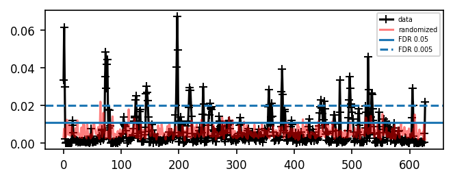

```python
# Now visualize the frontier index for the real data and the randomized frontier signal
fig, ax = plt.subplots(figsize=(5, 1.8))
ax.plot(compute_frontier_indexes(frontiers_matrix)[1], "k+-", label="data")

randomized_frontiers_matrix = (randomize_matrix(frontiers_matrix[0]),
                               randomize_matrix(frontiers_matrix[1]),
                               randomize_matrix(frontiers_matrix[2]))
ax.plot(compute_frontier_indexes(randomized_frontiers_matrix)[0],
        "r-", alpha=0.5, label="randomized")
ax.axhline(FDR[0.05], label="FDR 0.05");
ax.axhline(FDR[0.005], linestyle="--", label="FDR 0.005");
ax.legend(fontsize="xx-small");
fig.savefig("figures/FI_FDR.pdf")
```

Let's visualize the null distribution, the distribution of the statistics, and the 0.05 and 0.005 FDR threshold.

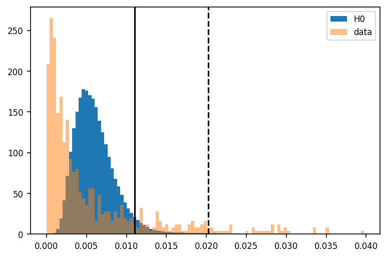

```python
fig, ax = plt.subplots()
frontiers_index = compute_frontier_indexes(frontiers_matrix)[1]
bins = np.linspace(
    min(min(maxima_rand_FI), min(frontiers_index)),
    max(max(maxima_rand_FI), min(frontiers_index)),
    100)
ax.hist(maxima_rand_FI, bins=bins, density=True, label="H0");
ax.hist(frontiers_index, bins=bins, density=True, alpha=0.5, label="data");
ax.axvline(FDR[0.05], c="#000000")
ax.axvline(FDR[0.005], c="#000000", linestyle="--")
ax.legend();
```

We can see that the null distribution and the distribution of the statistics from the data are fairly different from one another. In particular, the statistics obtained from the data are both much larger (corresponding to the presence of peaks) but also much smaller than the null statisics. This is a sign that the null statistics are being overestimated from the permutation procedure. The threshold obtained here will thus be conservative.

Now, get p-values from the permutation tests. The p-value for locus $i$ corresponds to the proportion of null statistics found above the value of the frontiers index. We then correct for multiple hypothesis testing using Benjamini-Hochberg.

```python
pvalues = np.sum(
    frontiers_index[:, np.newaxis] < maxima_rand_FI,
    axis=1) / len(maxima_rand_FI)
pvalues_adjusted = multipletests(pvalues, method="fdr_bh")[1]
significant_loci = np.where(pvalues_adjusted < 0.05)[0]
print("Number of loci with a significant frontier index (FDR=0.05):", len(significant_loci))
```

```
Number of loci with a significant frontier index (FDR=0.05): 36
```